# Projet Visualisation des données - Data Visualization ©

## Carte PM2,5 2012

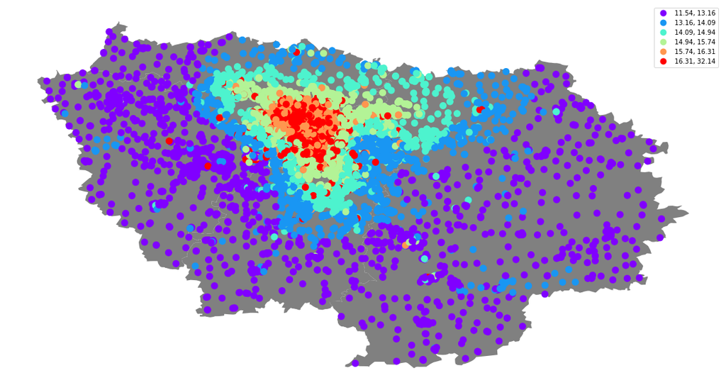

```python
carte_base = carte_IDF.plot( color = 'grey',figsize=(20,20))
geo2012.plot(ax=carte_base, column='PM25', legend=True,cmap= 'rainbow', scheme='quantiles',k=6, markersize=100).set_axis_off()
```

### On voit sur la carte qu'il y a un énorme dépassement des concentrations par rapport au seuil limite de 25 µg/m³ dans les écoles proche de Paris.

## Carte PM2,5 2017

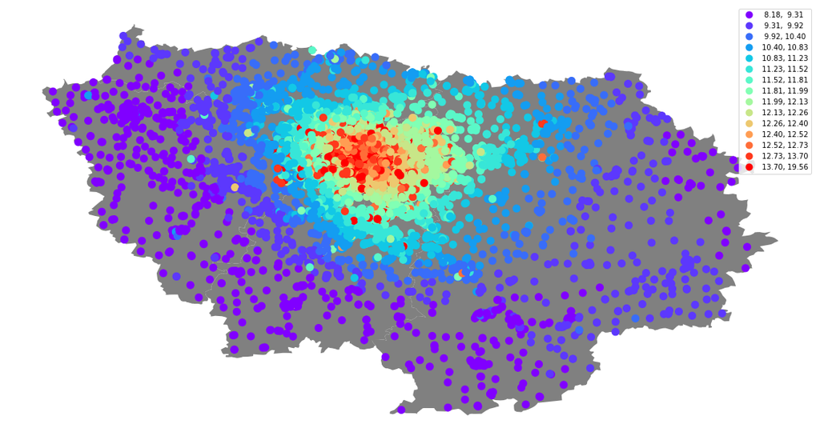

```python
carte_base = carte_IDF.plot( color = 'grey',figsize=(20,20))
geo2017.plot(ax=carte_base, column='PM25', legend=True,cmap= 'rainbow', scheme='quantiles',k=15,markersize=100).set_axis_off()
```

## Conclusion

### On voit que des efforts ont été fait entre 2012 et 2017 il y a une amélioration de la qualité de l'air globale en Île-de-France. Bien qu’on remarque également un contraste entre Paris, sa petite couronne et le reste de la région Île-de-France. En effet, dans les régions rurales la qualité est au rendez-vous, mais plus on se rapproche de la capitale plus l'air y est mauvais. Pour le bien des enfants, des efforts doivent encore être fait, il y a encore des établissement au dessus des seuils de pollution.